# Predict the manner

Jingjing Wang

2021/12/31

## Predict the manner

The goal of your project is to predict the manner in which they did the exercise. This is the “classe” variable in the training set. You may use any of the other variables to predict with. You should create a report describing how you built your model, how you used cross validation, what you think the expected out of sample error is, and why you made the choices you did. You will also use your prediction model to predict 20 different test cases.

The training data for this project are available here:

https://d396qusza40orc.cloudfront.net/predmachlearn/pml-training.csv

The test data are available here:

https://d396qusza40orc.cloudfront.net/predmachlearn/pml-testing.csv

The data for this project come from this source: http://groupware.les.inf.puc-rio.br/har.

The 1st step is the pull and cleanup the data.

```r
training <- read.csv("pml-training.csv",na.strings=c("NA","#DIV/0!", ""),stringsAsFactors=TRUE)
testing <- read.csv("pml-testing.csv",na.strings=c("NA","#DIV/0!", ""),stringsAsFactors=TRUE)
dim(training)
```

```
## [1] 19622   160
```

```r
dim(testing)
```

```
## [1]  20 160
```

```r
training <- training[ , colSums(is.na(training)) == 0]
testing <- testing[ , colSums(is.na(testing)) == 0]
dim(training)
```

```
## [1] 19622    60
```

```r
dim(testing)
```

```
## [1] 20 60
```

```r
library(tidyverse)
df_list <- list(training, testing)
cols <- reduce(df_list, .f = ~ intersect(colnames(.x), colnames(.y)))
training <- cbind(training[,cols],training[,"classe"])
colnames(training)[60]<-"classe"
testing <- cbind(testing[,cols],testing[,"problem_id"])
colnames(testing)[60]<-"problem_id"
training <- training[-c(1:7)]
testing <- testing[-c(1:7)]
```

For cross validation purpose, from the original training data, randomly select 70% for model training and select 30% for testing. The models will be verified with testing data, and select the most accurate one for prediction.

```r
set.seed(1000)
library(caret)
inTrain <- createDataPartition(y=training$classe, p=0.7, list=FALSE)
trainds <- training[inTrain,]
testds <- training[-inTrain,]
```

Using different models to train data, and cross validation to verify the accuracy and out of sample error.

Decision Tree:

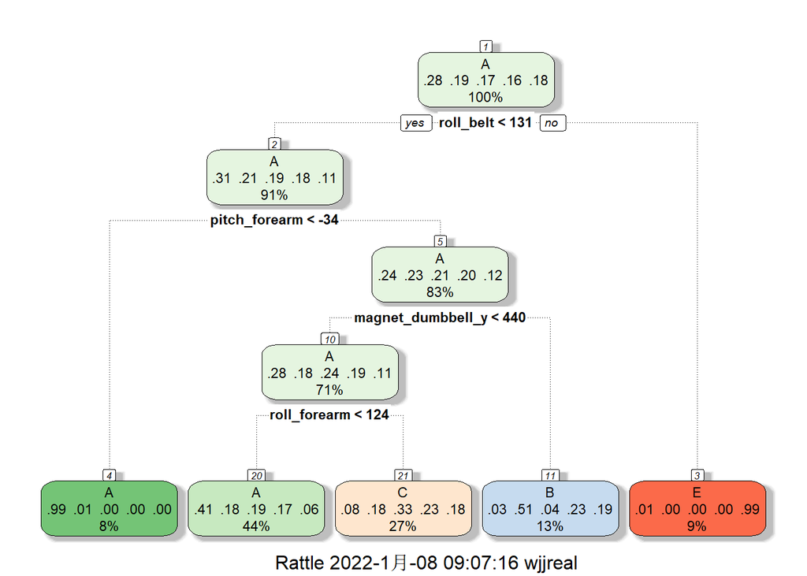

```r
library(rattle)
mod1 <- train(classe ~ ., method="rpart",data=trainds)
fancyRpartPlot(mod1$finalModel)
```

```r
pred1 <- predict(mod1,newdata=testds)
confusionMatrix(pred1, testds$classe)
```

```
## Confusion Matrix and Statistics
##
##           Reference
## Prediction    A    B    C    D    E
##          A 1523  487  474  445  173
##          B   27  396   34  165  154
##          C  121  256  518  354  291
##          D    0    0    0    0    0
##          E    3    0    0    0  464
##
## Overall Statistics
##
##                Accuracy : 0.4929
##                  95% CI : (0.4801, 0.5058)
##     No Information Rate : 0.2845
##     P-Value [Acc > NIR] : < 2.2e-16
##
##                   Kappa : 0.3366
##
##  Mcnemar's Test P-Value : NA
##
## Statistics by Class:
##
##                      Class: A Class: B Class: C Class: D Class: E
## Sensitivity            0.9098  0.34767  0.50487   0.0000  0.42884
## Specificity            0.6250  0.91993  0.78967   1.0000  0.99938
## Pos Pred Value         0.4910  0.51031  0.33636      NaN  0.99358
## Neg Pred Value         0.9457  0.85457  0.88308   0.8362  0.88594
## Prevalence             0.2845  0.19354  0.17434   0.1638  0.18386
## Detection Rate         0.2588  0.06729  0.08802   0.0000  0.07884
## Detection Prevalence   0.5271  0.13186  0.26168   0.0000  0.07935
## Balanced Accuracy      0.7674  0.63380  0.64727   0.5000  0.71411
```

The accuracy is 49.29% and out of sample error is 50.71%, try the next one.

Random Forest:

```r
library(parallel)
library(doParallel)
cluster <- makeCluster(5)
registerDoParallel(cluster)
fitControl <- trainControl(method = "cv",number = 5,allowParallel = TRUE)
system.time(mod2 <- train(classe ~ ., method="rf",data=trainds,prox=T,trControl = fitControl))
```

```
##   用户   系统   流逝
## 148.22  13.20 643.39
```

```r
stopCluster(cluster)
registerDoSEQ()
pred2 <- predict(mod2,newdata=testds)
confusionMatrix(pred2, testds$classe)
```

```
## Confusion Matrix and Statistics
##
##           Reference
## Prediction    A    B    C    D    E
##          A 1672    9    0    0    0
##          B    2 1125    3    1    0
##          C    0    5 1021    8    0
##          D    0    0    2  951    2
##          E    0    0    0    4 1080
##
## Overall Statistics
##
##                Accuracy : 0.9939
##                  95% CI : (0.9915, 0.9957)
##     No Information Rate : 0.2845
##     P-Value [Acc > NIR] : < 2.2e-16
##
##                   Kappa : 0.9923
##
##  Mcnemar's Test P-Value : NA
##
## Statistics by Class:
##
##                      Class: A Class: B Class: C Class: D Class: E
## Sensitivity            0.9988   0.9877   0.9951   0.9865   0.9982
## Specificity            0.9979   0.9987   0.9973   0.9992   0.9992
## Pos Pred Value         0.9946   0.9947   0.9874   0.9958   0.9963
## Neg Pred Value         0.9995   0.9971   0.9990   0.9974   0.9996
## Prevalence             0.2845   0.1935   0.1743   0.1638   0.1839
## Detection Rate         0.2841   0.1912   0.1735   0.1616   0.1835
## Detection Prevalence   0.2856   0.1922   0.1757   0.1623   0.1842
## Balanced Accuracy      0.9983   0.9932   0.9962   0.9929   0.9987
```

The accuracy is 99.39% and out of sample error is 0.61%. The result is very good. Try the next one to see if any chance better.

Linear Discriminant Analysis:

```r
mod3 <- train(classe ~ ., method="lda",data=trainds)
pred3 <- predict(mod3,newdata=testds)
confusionMatrix(pred3, testds$classe)
```

```
## Confusion Matrix and Statistics
##
##           Reference
## Prediction    A    B    C    D    E
##          A 1331  189   70   51   33
##          B   41  715  114   41  224
##          C  152  136  705  126   97
##          D  146   50  113  701  107
##          E    4   49   24   45  621
##
## Overall Statistics
##
##                Accuracy : 0.6921
##                  95% CI : (0.6801, 0.7039)
##     No Information Rate : 0.2845
##     P-Value [Acc > NIR] : < 2.2e-16
##
##                   Kappa : 0.611
##
##  Mcnemar's Test P-Value : < 2.2e-16
##
## Statistics by Class:
##
##                      Class: A Class: B Class: C Class: D Class: E
## Sensitivity            0.7951   0.6277   0.6871   0.7272   0.5739
## Specificity            0.9185   0.9115   0.8948   0.9155   0.9746
## Pos Pred Value         0.7951   0.6300   0.5798   0.6276   0.8358
## Neg Pred Value         0.9185   0.9107   0.9312   0.9448   0.9103
## Prevalence             0.2845   0.1935   0.1743   0.1638   0.1839
## Detection Rate         0.2262   0.1215   0.1198   0.1191   0.1055
## Detection Prevalence   0.2845   0.1929   0.2066   0.1898   0.1263
## Balanced Accuracy      0.8568   0.7696   0.7910   0.8213   0.7743
```

The accuracy is 69.21% and out of sample error is 30.79%, not good as random forest.

From the test result, random tree is the best model. The predict of testing data is as below.

```r
pred4 <- predict(mod2,newdata=testing)
pred4
```

```
##  [1] B A B A A E D B A A B C B A E E A B B B
## Levels: A B C D E
```